# Adrien HANS & Tanguy JEANNEAU

# Filtre de Kalman Etendu :

```python
import numpy as np
import matplotlib.pyplot as plt
from scipy.stats import norm
```

## 1) Pour la simulation :

On reprend les valeurs des paramètres :

$a_k=5$, amplitude de la sinusoïde

$\phi_k=0$, valeur de la phase de la sinusoïde

$\nu_0$, valeur de la fréquence de la sinusoïde

$\nu_e$=193.28 Hz, fréquence d'échantillonnage

Matrice de covariance de bruit d'état : $$Q=\begin{pmatrix} 2 10^{-5} &0 \\ 0 &2 10^{-1} \end{pmatrix}$$

Matrice de covariance du bruit de mesure:

$$R=3$$

Matrice décrivant la dynamique du système:

$$A=\begin{pmatrix} 1.0 &0 \\ 0 &1.0 \end{pmatrix}$$

```python
#Initialisation des paramètres :
Amplitude = 5
Phi = 0
Nu_e = 193.28
Nu_0 = 12
Te = 1 / Nu_e
nbEchantillon = 20000
t = np.arange(0, nbEchantillon , 1) * Te
```

```python
A = np.array([[1.0, 0.0],[0.0, 1.0]])
Q = np.array([[2e-5, 0.0],[0.0, 2e-1]])
```

```python
X = np.zeros(shape = (2, nbEchantillon))
Xhat = np.transpose([Amplitude, Phi])
X[:,0] = Xhat

# On applique l'équation qui caractérise la dynamique du système
for i in range(1, nbEchantillon, 1):
    X[:,i] = np.dot(A, X[:,i-1]) #+ np.transpose(np.random.multivariate_normal(np.transpose([0, 0]), Q))
```

```python
def equationMesure(x, t, Nu):
    Amplitude = x[0,:]
    Phi = x[1,:]
    Resultat = Amplitude * np.sin(2 * np.pi * Nu * t + Phi )
    return Resultat
```

```python
R = 3
sd = np.sqrt(R)
Y = np.zeros(shape = nbEchantillon)
# Calcul de la sortie réelle du système
# on applique l'équation de sortie
Y_real = equationMesure(X, t, Nu_0)
# Bruit de mesure
Bm = norm.rvs(0, sd, nbEchantillon)
# Calcul de la sortie bruitée
# Mesures dont on dispose pour faire l'estimation
Y = Y_real + Bm
```

On affiche le signal réel :

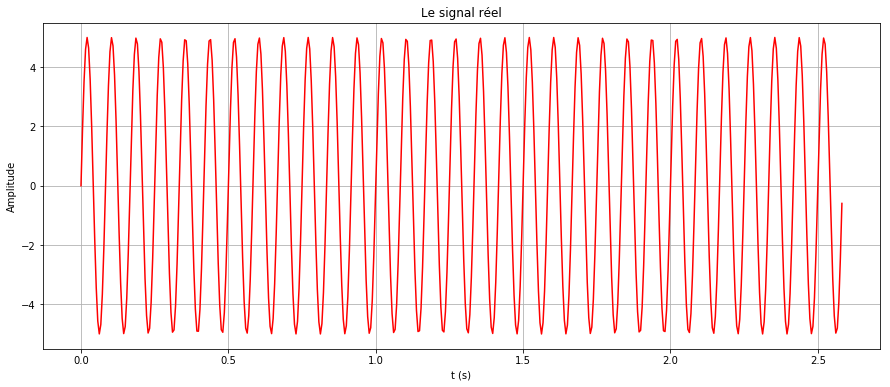

```python
limite = 500
fig=plt.figure(figsize=(15,6))
plt.plot(t[0:limite], Y_real[0:limite], 'r')
plt.title('Le signal réel')
plt.xlabel('t (s)')
plt.ylabel('Amplitude')
plt.grid()
plt.show()
```

On affiche les mesures bruitées :

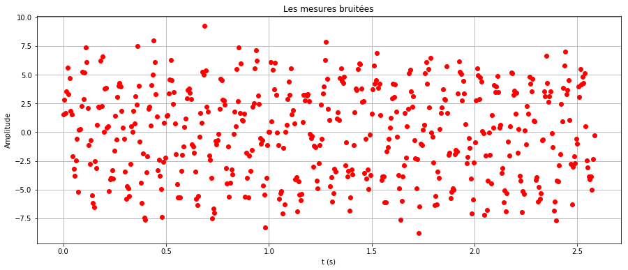

```python
limite = 500
fig=plt.figure(figsize=(15,6))
plt.plot(t[0:limite], Y[0:limite], 'ro')
plt.title('Les mesures bruitées')
plt.xlabel('t (s)')
plt.ylabel('Amplitude')
plt.grid()
plt.show()
```

On affiche le signal réel et les mesures bruitées :

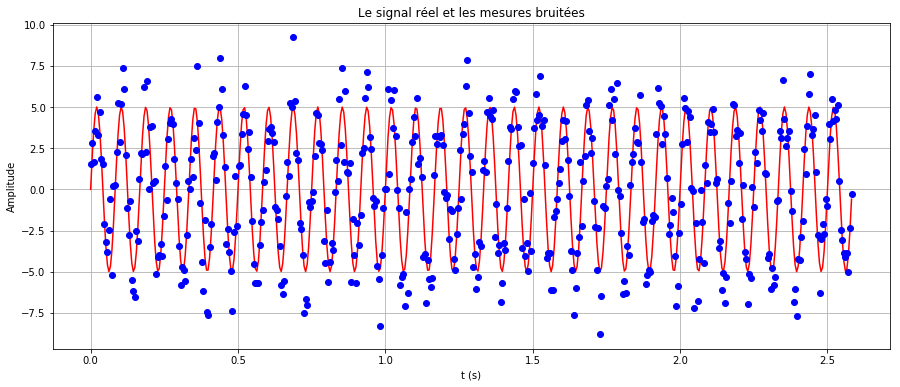

```python
limite = 500
fig=plt.figure(figsize=(15,6))
plt.plot(t[0:limite], Y_real[0:limite], 'r')
plt.plot(t[0:limite], Y[0:limite], 'bo')
plt.title('Le signal réel et les mesures bruitées')
plt.xlabel('t (s)')
plt.ylabel('Amplitude')
plt.grid()
plt.show()
```

## Mise en oeuvre du filtre :

En reprenant les principales étapes entrepris lors de la mise en place de l'introduction au filtre de Kalman lors du précèdent TP et en l'adaptant aux données du problème, notamment au fait qu'ici on se place en dimension deux pour l'estimation -on veut estimer l'amplitude et la phase du signal- on met en place l'algorithme du filtre de Kalman étendu :

```python
def Kalman(z=Y, R=R, Q=Q,Nu_0=Nu_0,Te=Te,limite=500):
    #Initialization :
    Lx_hat=np.zeros((2,limite))
    Lk=[0]
    #On initialise X :
    X=np.array([0,0])
    #signal z
    #P :
    P=np.array([[2, 0],[0, 1]])
    #compteur k :
    k=0
    Ly_hat=[X[0]*np.sin(2*np.pi*Nu_0*k*Te+X[1])]
    while k<limite:
        #vk bruit d'état ->np.random.normal(0,Q)
        X=X+sum(np.random.normal(0,Q))

        P=P+Q
        k+=1

        #formule pour H :
        H=np.array([np.sin(2*np.pi*Nu_0*k*Te + X[1]),X[0]*np.cos(2*np.pi*Nu_0*k*Te+X[1])])
        S=H.dot(P).dot(H.T)+R

        K=(P.dot(H.T))*(1/S)
        #Formule pour h :
        h=X[0]*np.sin(2*np.pi*Nu_0*k*Te+X[1])
        epsilon=z[k]-h
        X=X+K*epsilon
        P=P-(K*H.dot(P))


        Lx_hat[0,k-1]=X[0]
        Lx_hat[1,k-1]=X[1]
        Ly_hat.append(X[0]*np.sin(2*np.pi*Nu_0*k*Te+X[1]))
        Lk.append(k-1)
    return Lk, Lx_hat, Ly_hat
```

Comme lors du précèdent TP, on met en place une fonction `plt_Kalman` permettant d'afficher l'estimation, le signal réel et les mesures jusqu'à une certaine valeur `limite` que l'on précise.

```python
def plot_Kalman(z=Y, R=R, Q=Q,Nu_0=Nu_0,Te=Te, limite=500, z_real=Y_real):
    Lt, Lx_hat, Ly_hat = Kalman(z=Y, R=R, Q=Q,Nu_0=Nu_0,Te=Te, limite=limite)
    plt.figure(figsize=(15,5))
    plt.plot(Lt[0:limite], Ly_hat[0:limite], color='c',label= 'estimation')
    #plt.plot(Lt[0:limite], Y[0:limite], 'r', label='signal réel')
    plt.plot(Lt[0:limite], z_real[0:limite], 'r', label='signal réel')
    plt.plot(Lt[0:limite], z[0:limite], 'bo', label='Mesures', alpha=0.5)
    plt.title('Estimation du signal réel à partir des mesures :')
    plt.legend()
    plt.show()
    return Lt, Lx_hat, Ly_hat
```

## Simulation :

On simule l'algorithme avec une `limite = 200` afin de comparer le signal réel, les mesures, et le signal estimé :

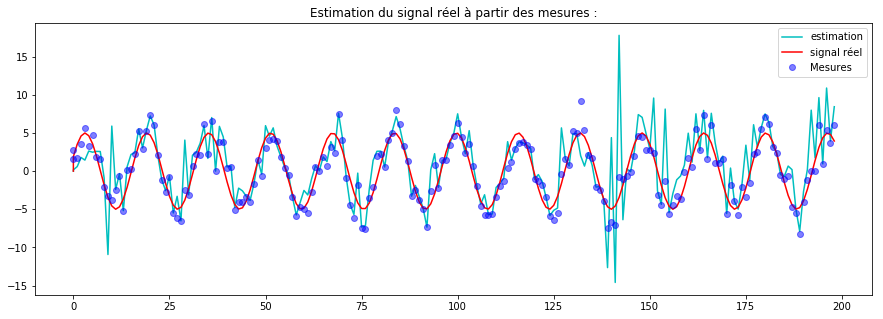

```python
limite=200
Lt, Lx_hat, Ly_hat=plot_Kalman(z=Y, R=R, Q=Q,Nu_0=Nu_0,Te=Te, limite=limite)
```

**Nous observons une divergence à certains endroits, avec une sensibilité très forte à certaines mesures.**

**On va donc essayer de savoir où se trouve le problème d'estimation, sur la phase ou sur l'amplitude :**

#### a) phase :

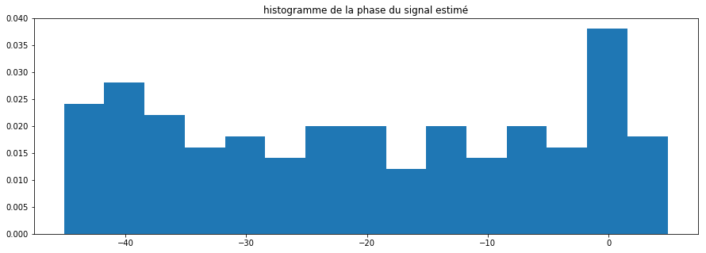

```python
fig=plt.figure(figsize=(15,5))
plt.hist(Lx_hat[1,0:150], bins=15, normed=True)
plt.title('histogramme de la phase du signal estimé')
plt.show()
```

```python
print('Moyenne de la phase sur tout le signal : {moy:.2f} '.format(moy=np.mean(Lx_hat[1,:])))
```

```
Moyenne de la phase sur tout le signal : -28.28
```

#### b) Amplitude :

On essaie observe l'histogramme de l'amplitude du signal estimé en affichant : $$|\hat{X}[0]|$$

C'est à la valeur absolue des élèments estimés correspondant à l'amplitude.

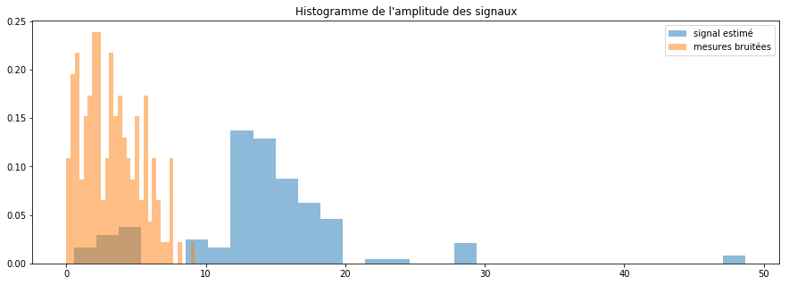

```python
fig=plt.figure(figsize=(15,5))
plt.hist(np.abs(Lx_hat[0,0:150]), bins=30, normed=True, alpha=0.5, label='signal estimé')
plt.hist(np.abs(Y[0:150]), bins=30, normed=True, alpha=0.5, label='mesures bruitées')
plt.title("Histogramme de l'amplitude des signaux")
plt.legend()
plt.show()
```

```python
print('Moyenne de la phase sur tout le signal : {moy:.2f} '.format(moy=np.mean(Lx_hat[0,:])))
```

```
Moyenne de la phase sur tout le signal : 22.47
```

#### c) Comparaison du signal estimé au signal bruité :

Nous comparons maintenant le signal estimé et le signal bruité à partir duquel on se propose d'estimer le signal réel.

En effet, même si des divergences sont notables entre le signal réel à estimer et l'estimation, on veut vérifier que le signal estimé estime quand même bien le signal bruité.

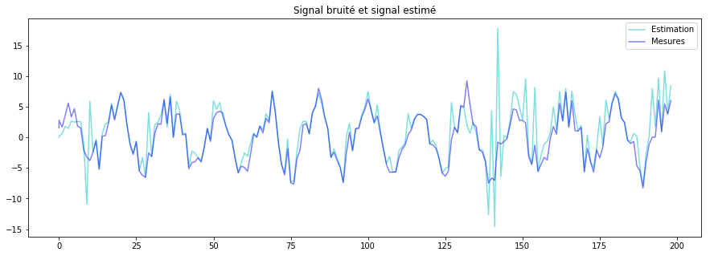

```python
fig=plt.figure(figsize=(15,5))
plt.title('Signal bruité et signal estimé')
plt.plot(Lt[0:limite], Ly_hat[0:limite], color='c',label= 'Estimation', alpha=0.5)
plt.plot(Lt[0:limite], Y[0:limite], 'b', label='Mesures', alpha=0.5)
plt.legend()
plt.show()
```

Nous observons sur cette échantillon que les courbes du signal estimé et du signal bruité à partir duquel on l'estime sont très proches, hormis lorsque des évènements extrêmes ou innatendus sont présents où dans ce cas la courbe du signal estimé 'décroche' complètement.

Voici un exemple de ces endroits :

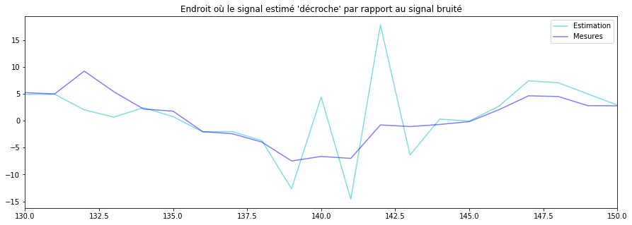

```python
fig,ax=plt.subplots(figsize=(15,5))
plt.title("Endroit où le signal estimé 'décroche' par rapport au signal bruité")
plt.plot(Lt[0:limite], Ly_hat[0:limite], color='c',label= 'Estimation', alpha=0.5)
plt.plot(Lt[0:limite], Y[0:limite],color='b', label='Mesures', alpha=0.5)
ax.set_xlim((130,150))
plt.legend()
plt.show()
```

De plus, on voit que le signal estimé a un peu de mal à reconverger directement vers les signal bruité lorsqu'il décroche, mais a plutôt tendance à faire un autre décrochage à l'opposé à la place, comme on le voit aussi plus haut.

**Cependant, point positif : le signal estimé ne fait pas que 'suivre' après coup le signal bruité qui lui sert de mesure, mais l'anticipe, comme le montre la figure ci-dessous :**

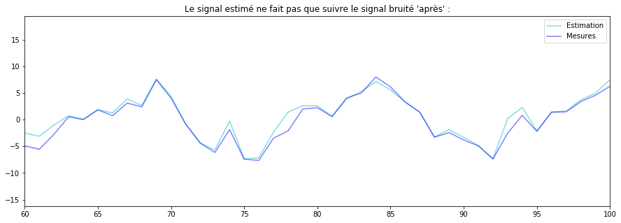

```python
fig,ax=plt.subplots(figsize=(15,5))
plt.title("Le signal estimé ne fait pas que suivre le signal bruité 'après' :")
plt.plot(Lt[0:limite], Ly_hat[0:limite], color='c',label= 'Estimation', alpha=0.5)
plt.plot(Lt[0:limite], Y[0:limite],color='b', label='Mesures', alpha=0.5)
ax.set_xlim((60,100))
plt.legend()
plt.show()
```

Cela explique sans doute les décrochages évoqués plus haut, le signal estimé ayant tendance à essayer de déterminer les variations futures en fonction de la dernière observation, les évènements extrèmes ou les variations 'brutes' ont forcément une forte tendance à faire décrocher le signal.

## Conclusion :

On observe une très grande sensibilité aux évènements extrêmes. En effet, les pics de mesures se retrouvant très inférieurs ou supérieurs ont tendance à entrainer des pics de bien plus grandes amplitude dans le signal estimé, qui éloignent completement du signal réel que l'on devait estimer.

On observe que c'est l'amplitude qui est la plus mal estimée entre la phase et l'amplitude.

On observe toujours des différences de signaux estimés en fonction des lancements de programme. Il faudrait donc sûrement, comme certains algorithmes le proposent, effectuer plusieurs simulations à chaque fois que l'un signal doit être estimé -10 lancements par exemple- et prendre le signal estimant le mieux.

Par contre, aucune régularité n'est enregistré par le signal estimé, cela est dû à la manière dont fonctionne l'algorithme et à cause aussi de la non-régularité des mesures à cause du bruit induit dans celles-ci.